# Diagnostics and Remedial Measures in $R$

# Read data from an URL

```r
toluca <- read.table("http://www.cnachtsheim-text.csom.umn.edu/Kutner/Chapter%20%201%20Data%20Sets/CH01TA01.txt", sep ="" , header = FALSE)


#Look at the first 6 entries
head(toluca)
```

```
  V1  V2
1 80 399
2 30 121
3 50 221
4 90 376
5 70 361
6 60 224
```

# Rename columns

```r
colnames(toluca) <- c("lotSize", "hours")

#Look at the first 6 entries
head(toluca)
```

```
  lotSize hours
1      80   399
2      30   121
3      50   221
4      90   376
5      70   361
6      60   224
```

# Convert your data into a `dataframe`

```r
tolucaDF <- data.frame(toluca)
head(tolucaDF)
```

```
  lotSize hours
1      80   399
2      30   121
3      50   221
4      90   376
5      70   361
6      60   224
```

# Diagnostic Plots for Predictor Variable-Toluca Company Example

## Dot plot

The dot plot for the lot sizes in the Toluca Company example.

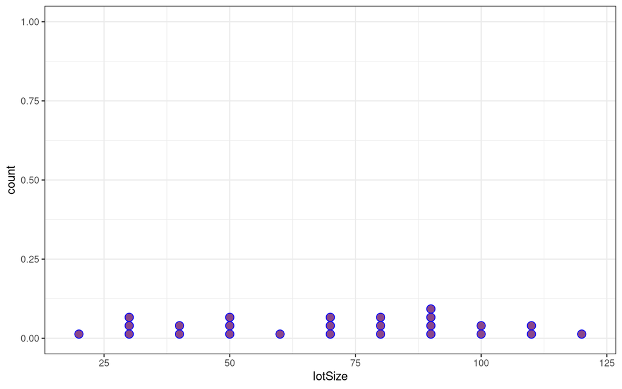

## Sequence plot

The Sequence plot for the lot sizes in the Toluca Company example.

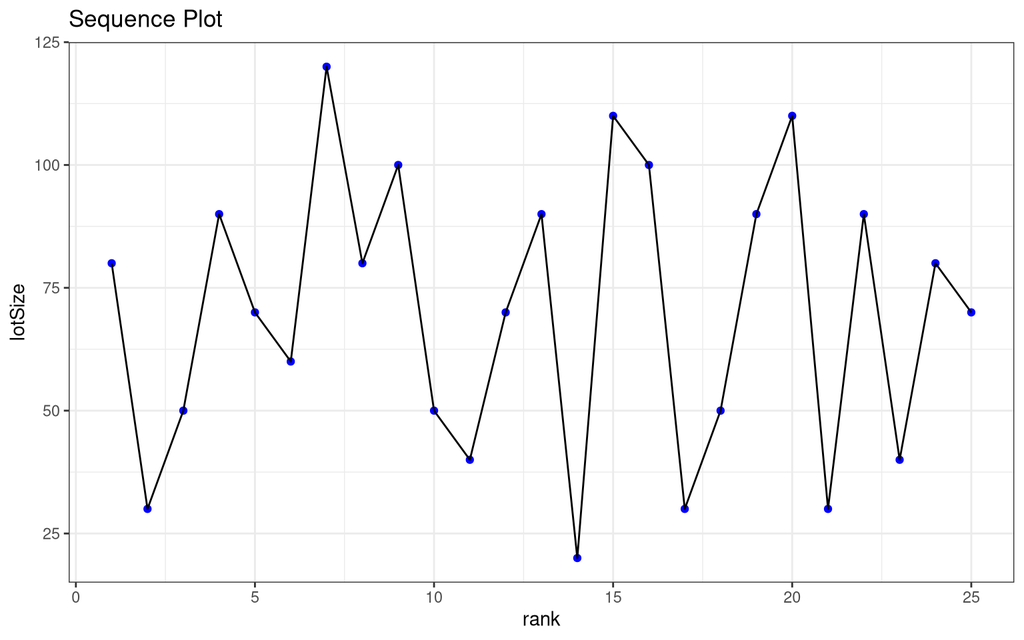

## Stem-and-leaf plot

Stem-and-leaf plot of the lot sizes for the Toluca Company example. By displaying the last digits, this plot also indicates here that all lot sizes in the Toluca Company example were multiples of 10.

```r
stem(tolucaDF$lotSize, scale = 3)
```

```
  The decimal point is 1 digit(s) to the right of the |

   2 | 0
   3 | 000
   4 | 00
   5 | 000
   6 | 0
   7 | 000
   8 | 000
   9 | 0000
  10 | 00
  11 | 00
  12 | 0
```

## Box plot

Box plot of the lot sizes for the Toluca Company example.

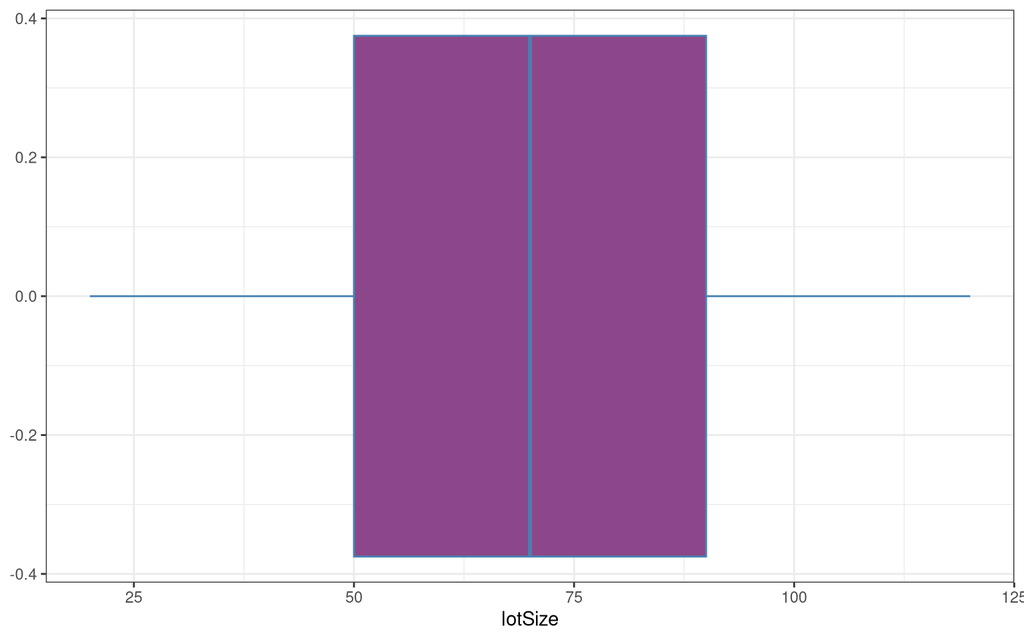

# Diagnostics for Residuals (Section 3.3 in the textbook)

## Normal probability plot of residuals.

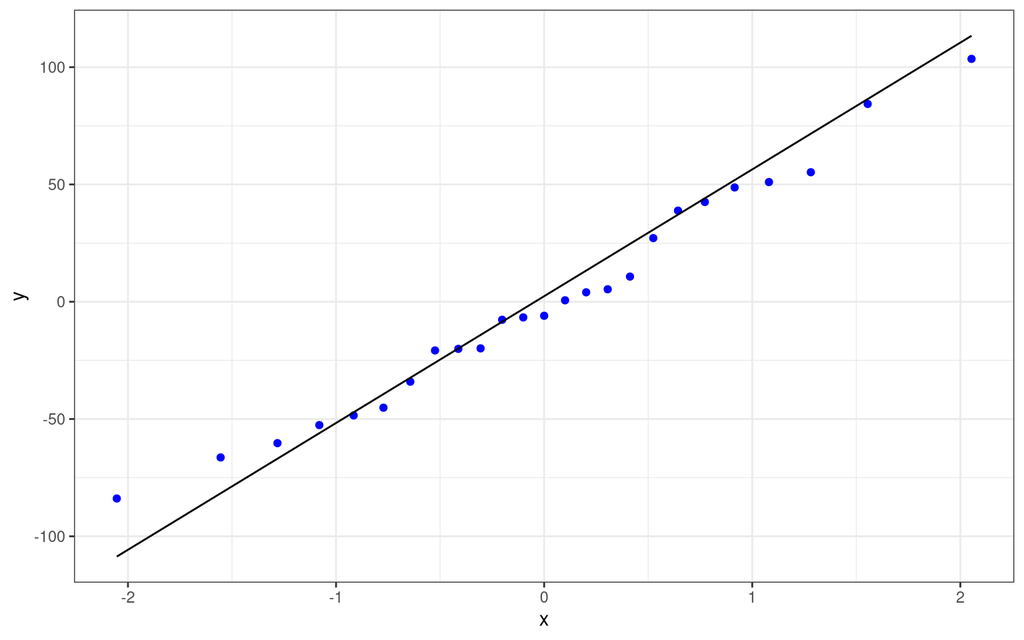

```r
ggplot(toluca_LS_model, aes(sample = .resid)) + geom_qq(color = "blue") + geom_qq_line()+ theme_bw() #No x or y aesthetics. Just use sample =.resid
```

## Nonnormality of Error Terms

$\mbox{Exp. Value under Normality} = \sqrt(MSE)[ z(\frac{k-0.375}{n+0.25})]$

Note that MSE can be calculated as the `SSE / DF`. Here I am using `deviance(toluca_LS_model)` to get `SSE` and `df.residual(toluca_LS_model)` to get the `DF`

```r
# Expected value under normality comes from equation (3.6)
tab <- cbind(
  "Residual"                   = round(resid(toluca_LS_model), 2), # rounding upresiduals to 2 decimal places
  "Rank"                       = rank(resid(toluca_LS_model)), # this is where we find k value
  "ExpValueunderNormality" = round(sqrt(deviance(toluca_LS_model) / df.residual(toluca_LS_model)) *
                                       qnorm((rank(resid(toluca_LS_model)) - 0.375) / (nrow(tolucaDF) + 0.25)), 2)) # deviance function finds the SSE and to find MSE we need to divide it by d.f. Then qnorm gives us the z value of (k-.375/n+.25). Again we have use round function to get final results in 2 decimal places.

tab
```

```
   Residual Rank ExpValueunderNormality
1     51.02   22                  51.97
2    -48.47    5                 -44.10
3    -19.88   10                 -14.76
4     -7.68   11                  -9.76
5     48.72   21                  44.10
6    -52.58    4                 -51.97
7     55.21   23                  61.48
8      4.02   15                   9.76
9    -66.39    2                 -74.17
10   -83.88    1                 -95.90
11   -45.17    6                 -37.25
12   -60.28    3                 -61.48
13     5.32   16                  14.76
14   -20.77    8                 -25.33
15   -20.09    9                 -19.93
16     0.61   14                   4.85
17    42.53   20                  37.25
18    27.12   18                  25.33
19    -6.68   12                  -4.85
20   -34.09    7                 -31.05
21   103.53   25                  95.90
22    84.32   24                  74.17
23    38.83   19                  31.05
24    -5.98   13                   0.00
25    10.72   17                  19.93
```

## Correlation Test for Normality

```r
res <- resid(toluca_LS_model)
expRes <- sqrt(deviance(toluca_LS_model) / df.residual(toluca_LS_model)) *
                                       qnorm((rank(resid(toluca_LS_model)) - 0.375) / (nrow(tolucaDF) + 0.25))
cor(res, expRes)
```

```
[1] 0.9915055
```

## Breusch-Pagan Test for Constancy of Error Variance

```r
library(lmtest)
bptest(toluca_LS_model, student = FALSE)
```

```
    Breusch-Pagan test

data:  toluca_LS_model
BP = 0.82092, df = 1, p-value = 0.3649
```

## Bank example section 3.7

```r
bankdata <- read.table("http://www.cnachtsheim-text.csom.umn.edu/Kutner/Chapter%20%203%20Data%20Sets/CH03TA04.txt", sep ="" , header = FALSE)


#Look at the first 6 entries
#head(bankdata)

#Rename clumns
colnames(bankdata) <- c("minDeposit", "NoNewAccs") # minDeposit - Size of minimum deposit, NoNewAccs - Number of new accounts

bankdata
```

```
   minDeposit NoNewAccs
1         125       160
2         100       112
3         200       124
4          75        28
5         150       152
6         175       156
7          75        42
8         175       124
9         125       150
10        200       104
11        100       136
```

```r
#Model
bankModel <- lm(NoNewAccs~minDeposit, data = bankdata)
bankModel
```

```
Call:
lm(formula = NoNewAccs ~ minDeposit, data = bankdata)

Coefficients:
(Intercept)   minDeposit
    50.7225       0.4867
```

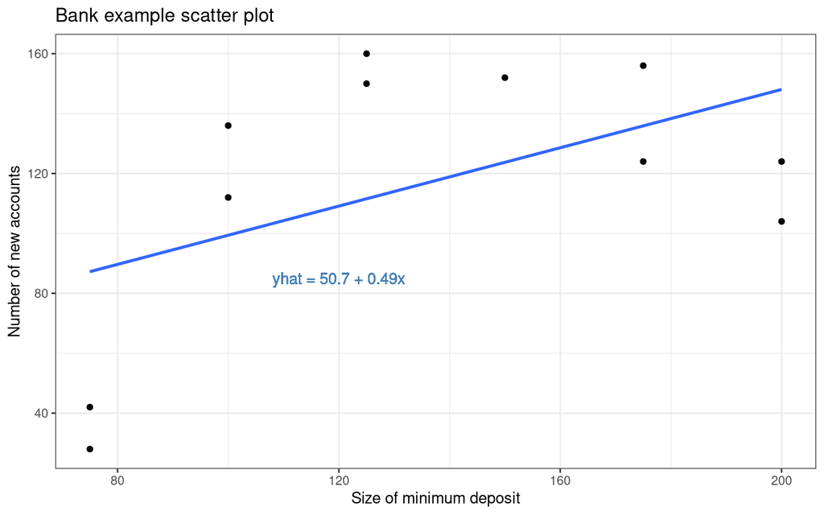

```r
#Scatter Plot
library(ggplot2)
library(latex2exp)

ggplot(bankdata, aes(x = minDeposit, y = NoNewAccs)) +
  geom_point() +
  labs(x = "Size of minimum deposit", y = "Number of new accounts", title = "Bank example scatter plot") +
  geom_smooth(method = "lm", se = FALSE) +
  geom_text(aes(x=120, label="yhat = 50.7 + 0.49x", y=85), colour="steelblue", angle=0, text=element_text(size=11)) +
  theme_bw()
```

### F test for lack of fit

```r
# F test for lack of fit

Reduced <- lm(NoNewAccs ~ minDeposit, data = bankdata) # This is our usual model
summary(Reduced)
```

```
##
## Call:
## lm(formula = NoNewAccs ~ minDeposit, data = bankdata)
##
## Residuals:
##    Min     1Q Median     3Q    Max
## -59.23 -34.06  12.61  32.44  48.44
##
## Coefficients:
##             Estimate Std. Error t value Pr(>|t|)
## (Intercept)  50.7225    39.3979   1.287     0.23
## minDeposit    0.4867     0.2747   1.772     0.11
##
## Residual standard error: 40.47 on 9 degrees of freedom
## Multiple R-squared:  0.2586, Adjusted R-squared:  0.1762
## F-statistic: 3.139 on 1 and 9 DF,  p-value: 0.1102
```

```r
Full <-  lm(NoNewAccs ~ 0 + as.factor(minDeposit), data = bankdata) # This is the full model
summary(Full)
```

```
##
## Call:
## lm(formula = NoNewAccs ~ 0 + as.factor(minDeposit), data = bankdata)
##
## Residuals:
##   1   2   3   4   5   6   7   8   9  10  11
##   5 -12  10  -7   0  16   7 -16  -5 -10  12
##
## Coefficients:
##                          Estimate Std. Error t value Pr(>|t|)
## as.factor(minDeposit)75     35.00      10.71   3.267 0.022282 *
## as.factor(minDeposit)100   124.00      10.71  11.573 8.45e-05 ***
## as.factor(minDeposit)125   155.00      10.71  14.466 2.85e-05 ***
## as.factor(minDeposit)150   152.00      15.15  10.031 0.000168 ***
## as.factor(minDeposit)175   140.00      10.71  13.066 4.68e-05 ***
## as.factor(minDeposit)200   114.00      10.71  10.640 0.000127 ***
## ---
## Signif. codes:  0 '***' 0.001 '**' 0.01 '*' 0.05 '.' 0.1 ' ' 1
##
## Residual standard error: 15.15 on 5 degrees of freedom
## Multiple R-squared:  0.9933, Adjusted R-squared:  0.9852
## F-statistic: 123.1 on 6 and 5 DF,  p-value: 2.893e-05
```

Testing the hypothesis:

$H_0: \mbox{Reduced model is good}$ $\quad$ $H_a: \mbox{Full model is good}$

```r
anova (Reduced, Full)
```

```
## Analysis of Variance Table
##
## Model 1: NoNewAccs ~ minDeposit
## Model 2: NoNewAccs ~ 0 + as.factor(minDeposit)
##   Res.Df   RSS Df Sum of Sq      F   Pr(>F)
## 1      9 14742
## 2      5  1148  4     13594 14.801 0.005594 **
## ---
## Signif. codes:  0 '***' 0.001 '**' 0.01 '*' 0.05 '.' 0.1 ' ' 1
```

### Example on page 129: Sales training example

```r
salesTrain <- read.table("http://www.cnachtsheim-text.csom.umn.edu/Kutner/Chapter%20%203%20Data%20Sets/CH03TA07.txt", sep ="" , header = FALSE)

#head(salesTrain)

#Rename columns
colnames(salesTrain) <- c("daysTrain", "performance")
head(salesTrain)
```

```
  daysTrain performance
1       0.5        42.5
2       0.5        50.6
3       1.0        68.5
4       1.0        80.7
5       1.5        89.0
6       1.5        99.6
```

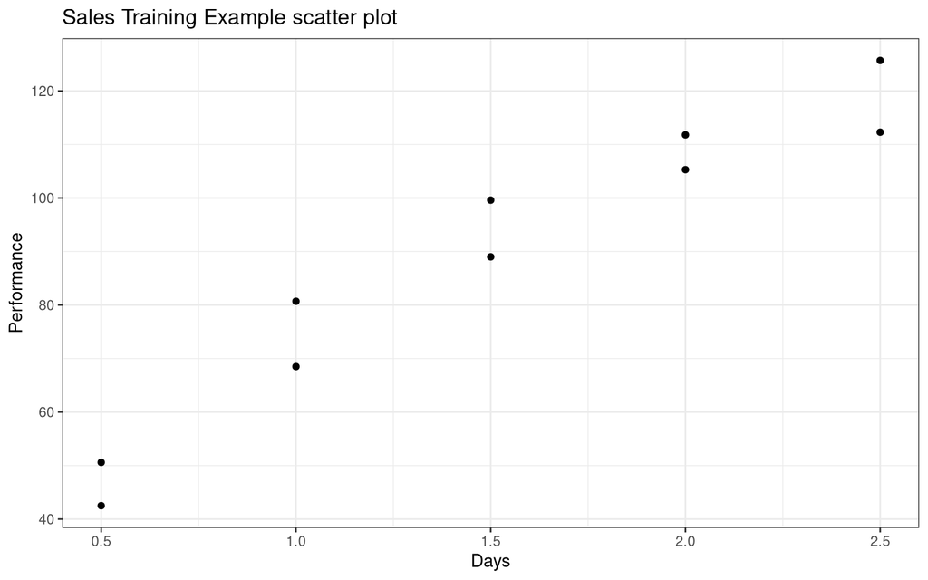

```r
# Create a scatter plot of these data in R
ggplot(salesTrain, aes(x = daysTrain, y = performance)) +
  geom_point() +
  labs(x = "Days", y = "Performance", title = "Sales Training Example scatter plot") +
  theme_bw()
```

- Do you see a linear relationship?
  - Clearly the regression relation appears to be curvilinear, so the simple linear regression model does not seem to be appropriate.
- What transformation might be appropriate for these data?
  - We shall consider a transformation on X. We shall consider initially the square root transformation (or go with the log 10 transformation of X)

```
   daysTrain performance daysTrainSqrt
1        0.5        42.5     0.7071068
2        0.5        50.6     0.7071068
3        1.0        68.5     1.0000000
4        1.0        80.7     1.0000000
5        1.5        89.0     1.2247449
6        1.5        99.6     1.2247449
7        2.0       105.3     1.4142136
8        2.0       111.8     1.4142136
9        2.5       112.3     1.5811388
10       2.5       125.7     1.5811388
```

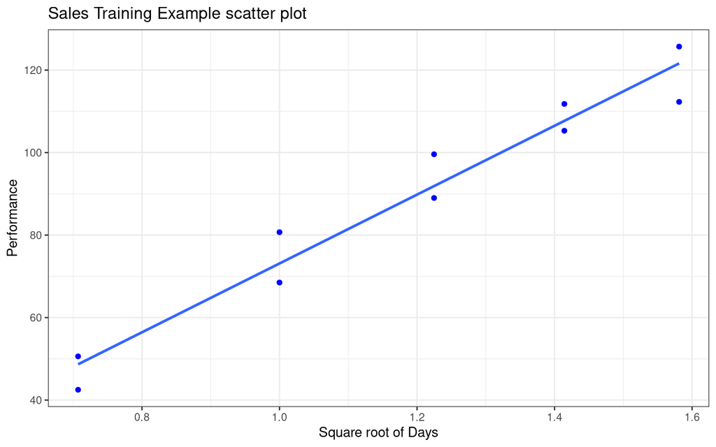

```
Call:
lm(formula = performance ~ daysTrainSqrt, data = salesTrainTrans)

Coefficients:
  (Intercept)  daysTrainSqrt
       -10.33          83.45
```

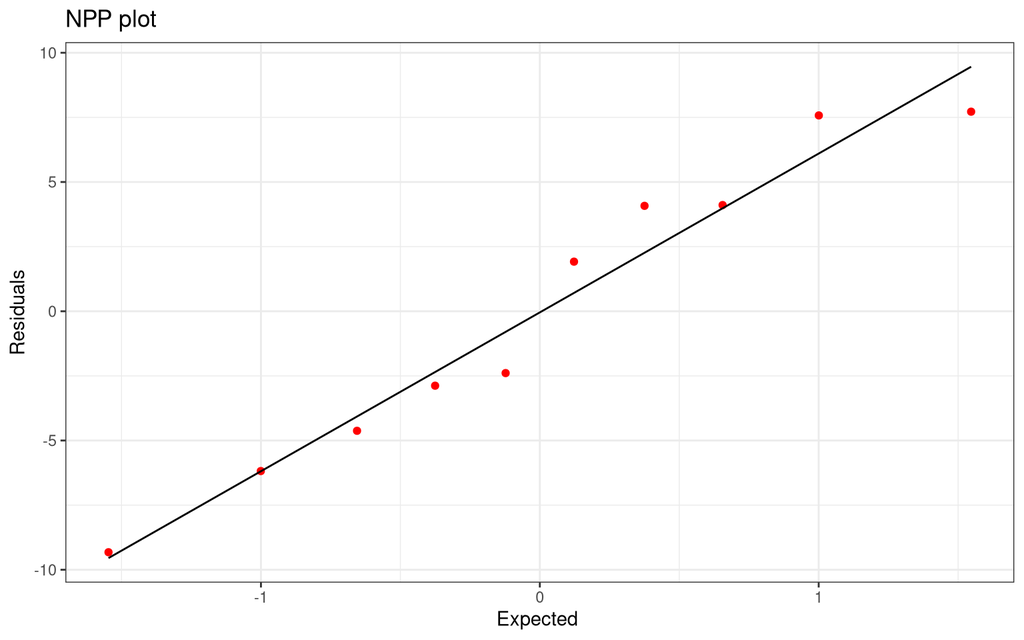

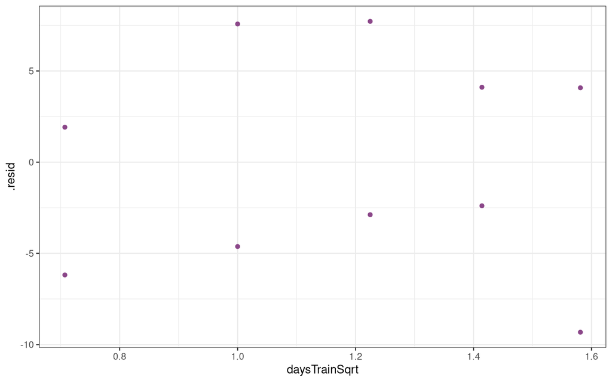

```
[1] 0.9789286
```

```
[1] 10
```

- Notice the correlation between residuals and expected residuals is 0.9789286.
  - The critical value when alpha = 0.01, is 0.879. (read from the table in the notes)
  - The correlation > critical value. Therefore, we conclude that the distribution of the error terms does not depart substantially from a normal distribution.
- Comment on lack of fit or of strong unequal error variances and normality
  - By looking at the residual plot there is no evidence of lack of fit or of strongly unequal error variances.
  - By looking at the NPP and above test, No strong indications of substantial departures from normality.